# Project Code

Team name

Author

Avanti Parkhe, Ava Serin, Emily Zhang, Ada Zhong

Published

February 27, 2023

Abstract

## 1 Data quality check / cleaning / preparation

Put code with comments. The comments should explain the code such that it can be easily understood. You may put text *(in a markdown cell)* before a large chunk of code to explain the overall purpose of the code, if it is not intuitive. **Put the name of the person / persons who contributed to each code chunk / set of code chunks.** An example is given below.

```python
import pandas as pd
import numpy as np
import statsmodels.formula.api as smf
import seaborn as sns
import matplotlib.pyplot as plt
from sklearn.linear_model import Ridge, RidgeCV, Lasso, LassoCV
from sklearn.preprocessing import StandardScaler
from sklearn.metrics import r2_score
import statsmodels.api as sm
```

```python
data = pd.read_csv('auto-mpg.csv')
```

### 1.1 Data quality check

*By Emily Zhang*

The code below visualizes the distribution of the variables in the dataset and checks for missing/null values.

```python
# checking for missing values
data.isnull().sum()
```

```
mpg             0
cylinders       0
displacement    0
horsepower      0
weight          0
acceleration    0
model year      0
origin          0
car name        0
dtype: int64
```

```python
# checking for NaN values
data.isna().sum()
```

```
mpg             0
cylinders       0
displacement    0
horsepower      0
weight          0
acceleration    0
model year      0
origin          0
car name        0
dtype: int64
```

```python
data.dtypes
```

```
mpg             float64
cylinders         int64
displacement    float64
horsepower       object
weight            int64
acceleration    float64
model year        int64
origin            int64
car name         object
dtype: object
```

```python
(data == '?').sum()
```

```
mpg             0
cylinders       0
displacement    0
horsepower      6
weight          0
acceleration    0
model year      0
origin          0
car name        0
dtype: int64
```

```python
#...Distribution of variables...#
categ = list(data.select_dtypes(include=['object']).columns)
nums = list(data.select_dtypes(exclude=['object']).columns)
print(f'categorical variables:  {categ}')
print(f'numerical variables:  {nums}')
```

```
categorical variables:  ['horsepower', 'car name']
numerical variables:  ['mpg', 'cylinders', 'displacement', 'weight', 'acceleration', 'model year', 'origin']
```

[output not shown]

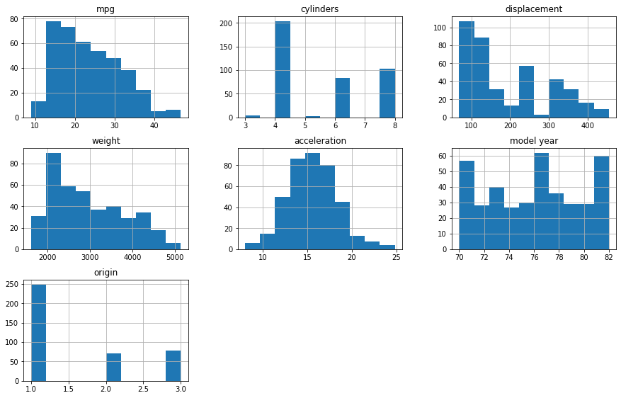

```python
#...Distribution of continuous variables...#
data.hist(figsize=(15,30),layout=(9,3))
```

```python
#...Distribution of categorical variable car name...#
data['car name'].value_counts()
```

```
ford pinto             6
toyota corolla         5
amc matador            5
ford maverick          5
chevrolet chevette     4
                      ..
chevrolet monza 2+2    1
ford mustang ii        1
pontiac astro          1
amc pacer              1
chevy s-10             1
Name: car name, Length: 305, dtype: int64
```

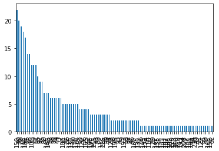

```python
# Distribution of categorical variable horsepower
data['horsepower'].value_counts().plot(kind='bar')
```

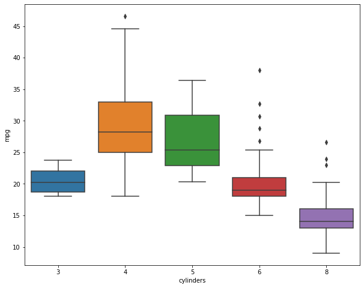

```python
# Cylinder to mpg to see relationship and distribution
plt.figure(figsize=(10,8))
sns.boxplot(x='cylinders',y='mpg',data=data)
```

### 1.2 Data cleaning

*By Emily Zhang*

From the data quality check we realized that:

1. We renamed `model year` and `car name` because these columns have spaces in them. We renamed them `model_year` and `car_name` so we can better call on these columns.
2. We binned the `cylinder` column with specific bins that we see from the distribution above.
3. There were some values in the `horsepower` column that were ‘?’. We replaced these with NaN to avoid errors in the code.
4. We changed the `horespower` column to be type float.
5. we mapped the `origin` column to country string names from key (found in Kaggle).

The code below implements the above cleaning.

```python
data.head()
```

|  | mpg | cylinders | displacement | horsepower | weight | acceleration | model year | origin | car name |
| --- | --- | --- | --- | --- | --- | --- | --- | --- | --- |
| 0 | 18.0 | 8 | 307.0 | 130 | 3504 | 12.0 | 70 | 1 | chevrolet chevelle malibu |
| 1 | 15.0 | 8 | 350.0 | 165 | 3693 | 11.5 | 70 | 1 | buick skylark 320 |
| 2 | 18.0 | 8 | 318.0 | 150 | 3436 | 11.0 | 70 | 1 | plymouth satellite |
| 3 | 16.0 | 8 | 304.0 | 150 | 3433 | 12.0 | 70 | 1 | amc rebel sst |
| 4 | 17.0 | 8 | 302.0 | 140 | 3449 | 10.5 | 70 | 1 | ford torino |

```python
# Renaming model year and car name column
data = data.rename(columns={'model year': 'model_year'})
data = data.rename(columns={'car name': 'car_name'})
```

```python
# Binning cylinder column
bins = [3,4,5,6,8]
data['cyl_binned'] = pd.cut(data['cylinders'],bins = bins)
```

```python
# Replace '?' with 'na'
data = data.replace('?', np.nan)
```

```python
# Convert columns from object to float datatype
data['horsepower'] = data['horsepower'].astype(float)
```

```python
# Mapping origin column to countries from key
data['origin'] = data['origin'].map({1: 'US', 2: 'Europe', 3: 'Asia'})
```

### 1.3 Data preparation

*By Ava Serin and Avanti Parkhe*

The following data preparation steps helped us to prepare our data for implementing various modeling / validation techniques:

We chose to do a best subset selection for all first-order predictors, forward stepwise selection for all first order and second-order interaction terms, and a ridge and lasso model. The data preparation for this is in the respective sections where this code is run.

## 2 Exploratory data analysis

Put code with comments. The comments should explain the code such that it can be easily understood. You may put text *(in a markdown cell)* before a large chunk of code to explain the overall purpose of the code, if it is not intuitive. **Put the name of the person / persons who contributed to each code chunk / set of code chunks.**

*By Emily Zhang*

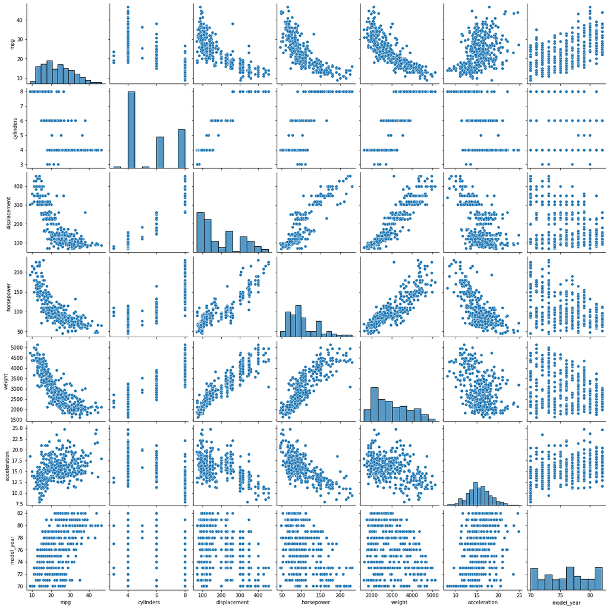

```python
# Pairplot to see correlation between predictors and response
sns.pairplot(data)
```

```python
data.corrwith(data.mpg)
```

```
mpg             1.000000
cylinders      -0.775396
displacement   -0.804203
horsepower     -0.778427
weight         -0.831741
acceleration    0.420289
model_year      0.579267
dtype: float64
```

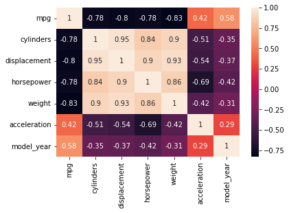

```python
corr = data.corr()
sns.heatmap(corr, annot = True)
```

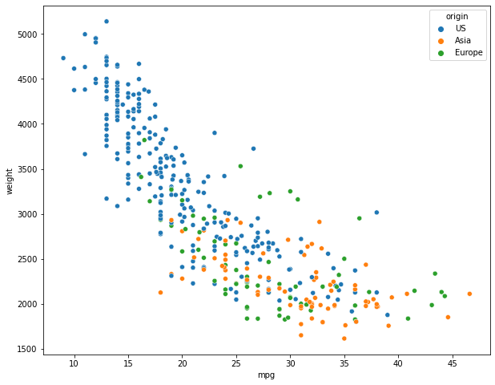

```python
# Weight to mpg with country as category
plt.figure(figsize=(10,8))
sns.scatterplot(x='mpg',y='weight',hue='origin',data=data)
```

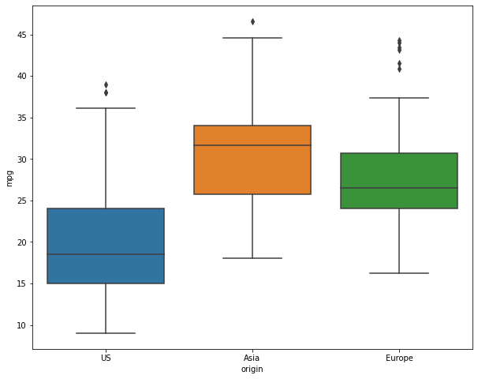

```python
# Country to mpg to see relationship and distribution
plt.figure(figsize=(10,8))
sns.boxplot(x='origin',y='mpg',data=data)
```

```python
# Split the data into training and test
np.random.seed(2)
train = data.sample(round(data.shape[0]*0.8)) # 80% of data in training set
test = data.drop(train.index)
```

```python
# VIF to detect multicollinearity
X = train[['cylinders', 'displacement', 'horsepower', 'weight', 'acceleration', 'model_year']]

from statsmodels.stats.outliers_influence import variance_inflation_factor
from statsmodels.tools.tools import add_constant

# Check for missing values and convert data to numeric type
X = X.apply(pd.to_numeric, errors='coerce')

# Drop rows with missing values
X = X.dropna()

X = add_constant(X)
vif_data = pd.DataFrame()
vif_data["feature"] = X.columns

for i in range(len(X.columns)):
    vif_data.loc[i,'VIF'] = variance_inflation_factor(X.values, i)

print(vif_data)
```

```
        feature         VIF
0         const  778.714466
1     cylinders   10.291058
2  displacement   18.886514
3    horsepower    9.285542
4        weight   10.587000
5  acceleration    2.549150
6    model_year    1.268785
```

## 3 Developing the model

Put code with comments. The comments should explain the code such that it can be easily understood. You may put text *(in a markdown cell)* before a large chunk of code to explain the overall purpose of the code, if it is not intuitive. **Put the name of the person / persons who contributed to each code chunk / set of code chunks.**

*By Ada Zhong*

#### 3.0.1 Model with all first-order predictors

```python
model1 = smf.ols(formula = 'mpg ~ cyl_binned + horsepower + weight + acceleration + model_year', data = train).fit()
model1.summary()
```

OLS Regression Results

| Dep. Variable: | mpg | R-squared: | 0.837 |
| --- | --- | --- | --- |
| Model: | OLS | Adj. R-squared: | 0.833 |
| Method: | Least Squares | F-statistic: | 220.0 |
| Date: | Sat, 11 Mar 2023 | Prob (F-statistic): | 3.74e-114 |
| Time: | 16:59:37 | Log-Likelihood: | -790.65 |
| No. Observations: | 308 | AIC: | 1597. |
| Df Residuals: | 300 | BIC: | 1627. |
| Df Model: | 7 |  |  |
| Covariance Type: | nonrobust |  |  |

|  | coef | std err | t | P>\|t\| | [0.025 | 0.975] |
| --- | --- | --- | --- | --- | --- | --- |
| Intercept | -10.1165 | 5.082 | -1.991 | 0.047 | -20.117 | -0.116 |
| cyl_binned[T.Interval(4, 5, closed='right')] | 1.4538 | 1.913 | 0.760 | 0.448 | -2.311 | 5.218 |
| cyl_binned[T.Interval(5, 6, closed='right')] | -3.0371 | 0.644 | -4.718 | 0.000 | -4.304 | -1.770 |
| cyl_binned[T.Interval(6, 8, closed='right')] | -0.1987 | 1.084 | -0.183 | 0.855 | -2.333 | 1.935 |
| horsepower | -0.0242 | 0.015 | -1.641 | 0.102 | -0.053 | 0.005 |
| weight | -0.0055 | 0.001 | -8.717 | 0.000 | -0.007 | -0.004 |
| acceleration | -0.0874 | 0.109 | -0.800 | 0.425 | -0.303 | 0.128 |
| model_year | 0.7198 | 0.056 | 12.844 | 0.000 | 0.609 | 0.830 |

| Omnibus: | 47.049 | Durbin-Watson: | 1.930 |
| --- | --- | --- | --- |
| Prob(Omnibus): | 0.000 | Jarque-Bera (JB): | 105.178 |
| Skew: | 0.765 | Prob(JB): | 1.45e-23 |
| Kurtosis: | 5.420 | Cond. No. | 8.71e+04 |

Notes:  
[1] Standard Errors assume that the covariance matrix of the errors is correctly specified.  
[2] The condition number is large, 8.71e+04. This might indicate that there are  
strong multicollinearity or other numerical problems.

```python
pred_mpg = model1.predict(test)
print("RMSE:", np.sqrt(((test.mpg - pred_mpg)**2).mean()))
```

```
RMSE: 3.259956505412606
```

#### 3.0.2 Model with quadratic term for weight

```python
model2 = smf.ols(formula = 'mpg ~ cyl_binned + horsepower + weight + I(weight**2) + acceleration + model_year', data = train).fit()
model2.summary()
```

OLS Regression Results

| Dep. Variable: | mpg | R-squared: | 0.864 |
| --- | --- | --- | --- |
| Model: | OLS | Adj. R-squared: | 0.860 |
| Method: | Least Squares | F-statistic: | 237.3 |
| Date: | Sat, 11 Mar 2023 | Prob (F-statistic): | 1.16e-124 |
| Time: | 16:59:37 | Log-Likelihood: | -762.81 |
| No. Observations: | 308 | AIC: | 1544. |
| Df Residuals: | 299 | BIC: | 1577. |
| Df Model: | 8 |  |  |
| Covariance Type: | nonrobust |  |  |

|  | coef | std err | t | P>\|t\| | [0.025 | 0.975] |
| --- | --- | --- | --- | --- | --- | --- |
| Intercept | 6.6001 | 5.133 | 1.286 | 0.199 | -3.500 | 16.701 |
| cyl_binned[T.Interval(4, 5, closed='right')] | 3.3077 | 1.767 | 1.872 | 0.062 | -0.170 | 6.785 |
| cyl_binned[T.Interval(5, 6, closed='right')] | -1.0815 | 0.641 | -1.686 | 0.093 | -2.344 | 0.181 |
| cyl_binned[T.Interval(6, 8, closed='right')] | -0.1170 | 0.992 | -0.118 | 0.906 | -2.070 | 1.836 |
| horsepower | -0.0219 | 0.014 | -1.617 | 0.107 | -0.048 | 0.005 |
| weight | -0.0197 | 0.002 | -10.219 | 0.000 | -0.023 | -0.016 |
| I(weight ** 2) | 2.171e-06 | 2.82e-07 | 7.698 | 0.000 | 1.62e-06 | 2.73e-06 |
| acceleration | -0.0915 | 0.100 | -0.915 | 0.361 | -0.288 | 0.105 |
| model_year | 0.7704 | 0.052 | 14.901 | 0.000 | 0.669 | 0.872 |

| Omnibus: | 58.498 | Durbin-Watson: | 1.918 |
| --- | --- | --- | --- |
| Prob(Omnibus): | 0.000 | Jarque-Bera (JB): | 150.434 |
| Skew: | 0.888 | Prob(JB): | 2.16e-33 |
| Kurtosis: | 5.927 | Cond. No. | 3.44e+08 |

Notes:  
[1] Standard Errors assume that the covariance matrix of the errors is correctly specified.  
[2] The condition number is large, 3.44e+08. This might indicate that there are  
strong multicollinearity or other numerical problems.

```python
pred_mpg = model2.predict(test)
print("RMSE:", np.sqrt(((test.mpg - pred_mpg)**2).mean()))
```

```
RMSE: 3.046131472460539
```

#### 3.0.3 Model with quadratic terms for horsepower and weight

```python
model3 = smf.ols(formula = 'mpg ~ horsepower + I(horsepower**2) + weight + I(weight**2) + acceleration + model_year', data = train).fit()
model3.summary()
```

OLS Regression Results

| Dep. Variable: | mpg | R-squared: | 0.860 |
| --- | --- | --- | --- |
| Model: | OLS | Adj. R-squared: | 0.857 |
| Method: | Least Squares | F-statistic: | 312.7 |
| Date: | Sat, 11 Mar 2023 | Prob (F-statistic): | 4.53e-127 |
| Time: | 16:59:37 | Log-Likelihood: | -775.43 |
| No. Observations: | 312 | AIC: | 1565. |
| Df Residuals: | 305 | BIC: | 1591. |
| Df Model: | 6 |  |  |
| Covariance Type: | nonrobust |  |  |

|  | coef | std err | t | P>\|t\| | [0.025 | 0.975] |
| --- | --- | --- | --- | --- | --- | --- |
| Intercept | 9.6930 | 5.101 | 1.900 | 0.058 | -0.345 | 19.731 |
| horsepower | -0.1949 | 0.043 | -4.558 | 0.000 | -0.279 | -0.111 |
| I(horsepower ** 2) | 0.0006 | 0.000 | 4.386 | 0.000 | 0.000 | 0.001 |
| weight | -0.0156 | 0.002 | -7.504 | 0.000 | -0.020 | -0.011 |
| I(weight ** 2) | 1.691e-06 | 2.98e-07 | 5.678 | 0.000 | 1.1e-06 | 2.28e-06 |
| acceleration | -0.2205 | 0.107 | -2.057 | 0.041 | -0.431 | -0.010 |
| model_year | 0.7938 | 0.051 | 15.528 | 0.000 | 0.693 | 0.894 |

| Omnibus: | 42.772 | Durbin-Watson: | 1.939 |
| --- | --- | --- | --- |
| Prob(Omnibus): | 0.000 | Jarque-Bera (JB): | 90.292 |
| Skew: | 0.711 | Prob(JB): | 2.47e-20 |
| Kurtosis: | 5.218 | Cond. No. | 3.41e+08 |

Notes:  
[1] Standard Errors assume that the covariance matrix of the errors is correctly specified.  
[2] The condition number is large, 3.41e+08. This might indicate that there are  
strong multicollinearity or other numerical problems.

```python
pred_mpg = model3.predict(test)
print("RMSE:", np.sqrt(((test.mpg - pred_mpg)**2).mean()))
```

```
RMSE: 2.9521676150409695
```

#### 3.0.4 Model with mpg logged and above quadratic transformations

```python
model4 = smf.ols(formula = 'np.log(mpg) ~ horsepower + I(horsepower**2) + weight + I(weight**2) + acceleration + model_year', data = train).fit()
model4.summary()
```

OLS Regression Results

| Dep. Variable: | np.log(mpg) | R-squared: | 0.888 |
| --- | --- | --- | --- |
| Model: | OLS | Adj. R-squared: | 0.885 |
| Method: | Least Squares | F-statistic: | 401.4 |
| Date: | Sat, 11 Mar 2023 | Prob (F-statistic): | 1.66e-141 |
| Time: | 16:59:37 | Log-Likelihood: | 237.49 |
| No. Observations: | 312 | AIC: | -461.0 |
| Df Residuals: | 305 | BIC: | -434.8 |
| Df Model: | 6 |  |  |
| Covariance Type: | nonrobust |  |  |

|  | coef | std err | t | P>\|t\| | [0.025 | 0.975] |
| --- | --- | --- | --- | --- | --- | --- |
| Intercept | 2.3684 | 0.198 | 11.932 | 0.000 | 1.978 | 2.759 |
| horsepower | -0.0062 | 0.002 | -3.726 | 0.000 | -0.009 | -0.003 |
| I(horsepower ** 2) | 1.597e-05 | 5.26e-06 | 3.037 | 0.003 | 5.62e-06 | 2.63e-05 |
| weight | -0.0005 | 8.07e-05 | -5.645 | 0.000 | -0.001 | -0.000 |
| I(weight ** 2) | 3.606e-08 | 1.16e-08 | 3.112 | 0.002 | 1.33e-08 | 5.89e-08 |
| acceleration | -0.0098 | 0.004 | -2.358 | 0.019 | -0.018 | -0.002 |
| model_year | 0.0308 | 0.002 | 15.500 | 0.000 | 0.027 | 0.035 |

| Omnibus: | 7.576 | Durbin-Watson: | 1.999 |
| --- | --- | --- | --- |
| Prob(Omnibus): | 0.023 | Jarque-Bera (JB): | 12.597 |
| Skew: | -0.007 | Prob(JB): | 0.00184 |
| Kurtosis: | 3.984 | Cond. No. | 3.41e+08 |

Notes:  
[1] Standard Errors assume that the covariance matrix of the errors is correctly specified.  
[2] The condition number is large, 3.41e+08. This might indicate that there are  
strong multicollinearity or other numerical problems.

```python
pred_mpg = np.exp(model4.predict(test))
np.sqrt(((test.mpg - pred_mpg)**2).mean())
```

```
3.00382011654809
```

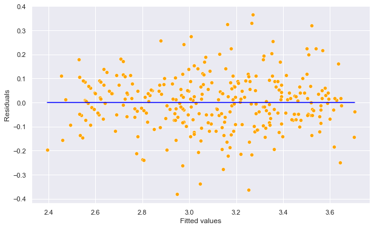

```python
#Plotting residuals vs fitted values
sns.set(rc={'figure.figsize':(10,6)})
sns.scatterplot(x = (model4.fittedvalues), y=(model4.resid),color = 'orange')
sns.lineplot(x = [model4.fittedvalues.min(),model4.fittedvalues.max()],y = [0,0],color = 'blue')
plt.xlabel('Fitted values')
plt.ylabel('Residuals')
```

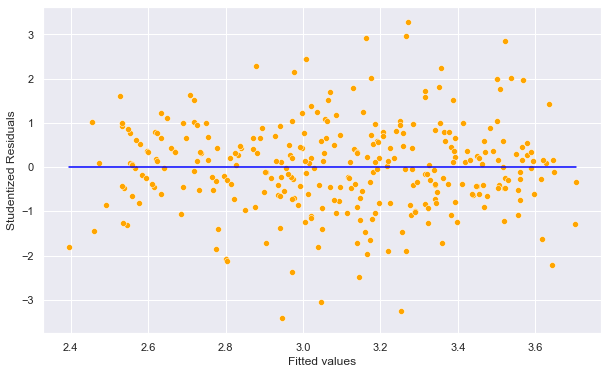

```python
#Studentized residuals
out = model4.outlier_test()

#Plotting studentized residuals vs fitted values
sns.scatterplot(x = (model4.fittedvalues), y=(out.student_resid),color = 'orange')
sns.lineplot(x = [model4.fittedvalues.min(),model4.fittedvalues.max()],y = [0,0],color = 'blue')
plt.xlabel('Fitted values')
plt.ylabel('Studentized Residuals')
```

```python
# Number of points with absolute studentized residuals greater than 3
np.sum((np.abs(out.student_resid)>3))
```

```
4
```

```python
# Computing the leverage statistic for each observation
influence = model4.get_influence()
leverage = influence.hat_matrix_diag
```

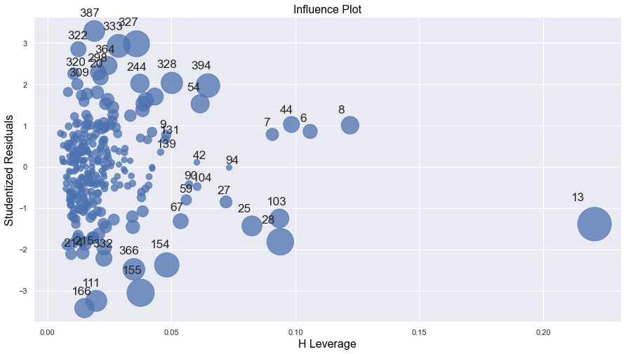

```python
# Visualizng leverage against studentized residuals
sns.set(rc={'figure.figsize':(15,8)})
sm.graphics.influence_plot(model4);
```

```python
out = model4.outlier_test()
average_leverage = (model4.df_model+1)/model4.nobs
high_leverage_threshold = 4*average_leverage
print("Number of high leverage points:", np.sum(leverage>high_leverage_threshold))
```

```
Number of high leverage points: 7
```

### 3.1 Predictor Selection

*By Avanti Parkhe and Ava Serin*

#### 3.1.1 Best Subset Selection using First-Order Predictors

```python
# Creating new dataframes for the interactions
train_selection = train.copy()
test_selection = test.copy()

# Creating datasets for forward stepwise regression
train_fwd = train.copy()
test_fwd = test.copy()
```

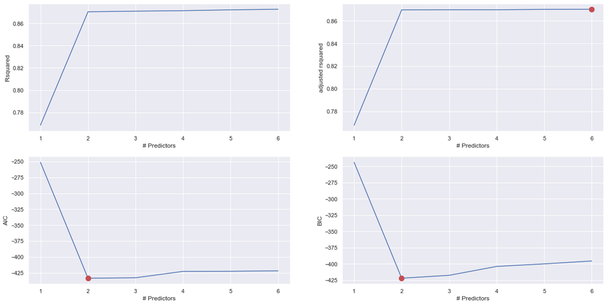

```python
# Doing a stepwise selection with first-order predictors
import time
import itertools

X = train_selection[["cylinders", "displacement", "horsepower", "weight", "acceleration", "model_year"]]

def processSubset(predictor_subset):
    model = smf.ols('np.log(mpg)~' + '+'.join(predictor_subset),data = train_selection).fit()
    Rsquared = model.rsquared
    return {"model":model, "Rsquared":Rsquared}

def getBest_model(k):
    tic = time.time()
    results = []
    for combo in itertools.combinations(X.columns, k):
        results.append(processSubset((list(combo))))

    models = pd.DataFrame(results)

    best_model = models.loc[models['Rsquared'].argmax()]

    toc = time.time()
    return best_model

models_best = pd.DataFrame(columns=["Rsquared", "model"])

tic = time.time()
for i in range(1,1+X.shape[1]):
    models_best.loc[i] = getBest_model(i)

toc = time.time()

def best_sub_plots():
    plt.figure(figsize=(20,10))
    plt.rcParams.update({'font.size': 18, 'lines.markersize': 10})

    plt.subplot(2, 2, 1)

    plt.plot(models_best["Rsquared"])
    plt.xlabel('# Predictors')
    plt.ylabel('Rsquared')

    rsquared_adj = models_best.apply(lambda row: row[1].rsquared_adj, axis=1)

    plt.subplot(2, 2, 2)
    plt.plot(rsquared_adj)
    plt.plot(1+rsquared_adj.argmax(), rsquared_adj.max(), "or")
    plt.xlabel('# Predictors')
    plt.ylabel('adjusted rsquared')

    aic = models_best.apply(lambda row: row[1].aic, axis=1)

    plt.subplot(2, 2, 3)
    plt.plot(aic)
    plt.plot(1+aic.argmin(), aic.min(), "or")
    plt.xlabel('# Predictors')
    plt.ylabel('AIC')

    bic = models_best.apply(lambda row: row[1].bic, axis=1)

    plt.subplot(2, 2, 4)
    plt.plot(bic)
    plt.plot(1+bic.argmin(), bic.min(), "or")
    plt.xlabel('# Predictors')
    plt.ylabel('BIC')
best_sub_plots()
```

We are using BIC for selecting the best number of predictors. Therefore, we will be using 2 predictors.

```python
best_subset_model = models_best.loc[2,'model']
models_best.loc[2,'model'].summary()
```

OLS Regression Results

| Dep. Variable: | np.log(mpg) | R-squared: | 0.870 |
| --- | --- | --- | --- |
| Model: | OLS | Adj. R-squared: | 0.870 |
| Method: | Least Squares | F-statistic: | 1057. |
| Date: | Sat, 11 Mar 2023 | Prob (F-statistic): | 1.88e-140 |
| Time: | 16:59:38 | Log-Likelihood: | 219.74 |
| No. Observations: | 318 | AIC: | -433.5 |
| Df Residuals: | 315 | BIC: | -422.2 |
| Df Model: | 2 |  |  |
| Covariance Type: | nonrobust |  |  |

|  | coef | std err | t | P>\|t\| | [0.025 | 0.975] |
| --- | --- | --- | --- | --- | --- | --- |
| Intercept | 1.6342 | 0.161 | 10.121 | 0.000 | 1.316 | 1.952 |
| weight | -0.0003 | 8.61e-06 | -35.203 | 0.000 | -0.000 | -0.000 |
| model_year | 0.0311 | 0.002 | 15.723 | 0.000 | 0.027 | 0.035 |

| Omnibus: | 7.293 | Durbin-Watson: | 2.052 |
| --- | --- | --- | --- |
| Prob(Omnibus): | 0.026 | Jarque-Bera (JB): | 10.764 |
| Skew: | -0.120 | Prob(JB): | 0.00460 |
| Kurtosis: | 3.869 | Cond. No. | 7.32e+04 |

Notes:  
[1] Standard Errors assume that the covariance matrix of the errors is correctly specified.  
[2] The condition number is large, 7.32e+04. This might indicate that there are  
strong multicollinearity or other numerical problems.

```python
#Finding the RMSE of the model selected using the best subset selection procedure
pred_mpg = np.exp(best_subset_model.predict(test))
print("RMSE of best subset model", np.sqrt(((pred_mpg - test.mpg)**2).mean()))

#RMSE of the model using all the predictors
model = smf.ols('np.log(mpg)~' + '+'.join(X.columns),data = train).fit()
pred_mpg = np.exp(model.predict(test))
print("RMSE using all predictors", np.sqrt(((pred_mpg - test.mpg)**2).mean()))
```

```
RMSE of best subset model 3.1836334350915054
RMSE using all predictors 3.217250646800846
```

#### 3.1.2 Lasso Regression

```python
# Copying dfs to drop na values
train2 = train.copy()
test2 = test.copy()

train2 = train2.dropna()
test2 = test2.dropna()
```

```python
#Taking the log transform of mpg as its frequency has a right-skewed distribution
y = np.log(train2.mpg)

#Filtering all predictors
excluded_cols = ["car_name","origin","cyl_binned","mpg"]

selected_cols = [col for col in train2.columns if col not in excluded_cols]
X = train2[selected_cols]

#Standardizing predictors so that each of them have zero mean and unit variance
#Defining a scaler object
scaler = StandardScaler()

#The scaler object will contain the mean and variance of each column (predictor) of X.
#These values will be useful to scale test data2 based on the same mean and variance as obtained on train2 data2
scaler.fit(X)

#Using the scaler object (or the values of mean and variance stored in it) to standardize X (or train2 data2)
Xstd = scaler.transform(X)
```

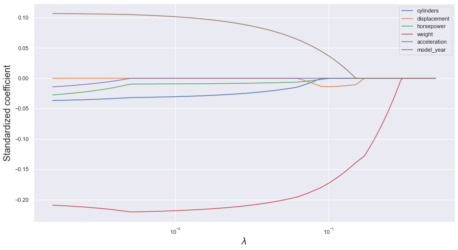

```python
#Finding the lasso coefficients for increasing values of the tuning parameter

#The tuning parameter lambda is referred as alpha in sklearn

#Creating a range of values of the tuning parameter to visualize the ridge regression coefficients
#for different values of the tuning parameter
alphas = 10**np.linspace(0,-2.5,200)*0.5
lasso = Lasso(max_iter = 10000)
coefs = []

for a in alphas:
    lasso.set_params(alpha=a)
    lasso.fit(Xstd, y)
    coefs.append(lasso.coef_)

#Visualizing the shrinkage in lasso coefficients with increasing values of the tuning parameter lambda
plt.xlabel('xlabel', fontsize=18)
plt.ylabel('ylabel', fontsize=18)
plt.plot(alphas, coefs)
plt.xscale('log')
plt.xlabel('$\lambda$')
plt.ylabel('Standardized coefficient')
plt.legend(train2[selected_cols]);
plt.legend(train2[selected_cols]);
```

```python
#Let us use cross validation to find the optimal value of the tuning parameter - lambda
#For the optimal lambda, the cross validation error will be the least

#Note that we are reducing the range of alpha so as to better visualize the minimum

lassocv = LassoCV(alphas = alphas, cv = 10, max_iter = 100000)
lassocv.fit(Xstd, y)

#Optimal value of the tuning parameter - lamda
lassocv.alpha_
```

```
0.00871316693004825
```

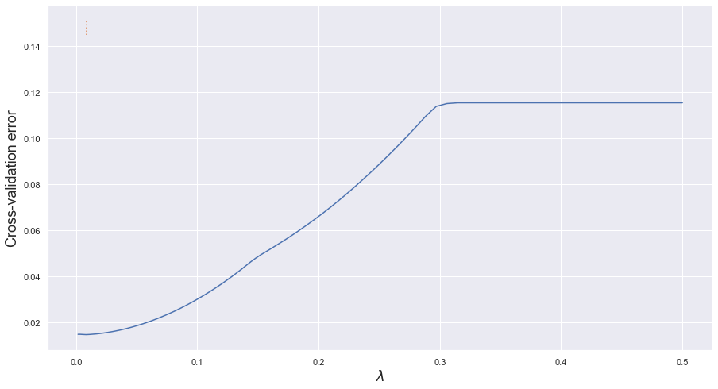

```python
#Visualizing the LOOCV (leave one out cross validatation error vs lambda)
plt.xlabel('xlabel', fontsize=18)
plt.ylabel('ylabel', fontsize=18)
plt.plot(lassocv.alphas_,lassocv.mse_path_.mean(axis=1))
plt.plot([lassocv.alpha_,lassocv.alpha_],[0.145,0.151],':')
plt.xlabel('$\lambda$')
plt.ylabel('Cross-validation error')
```

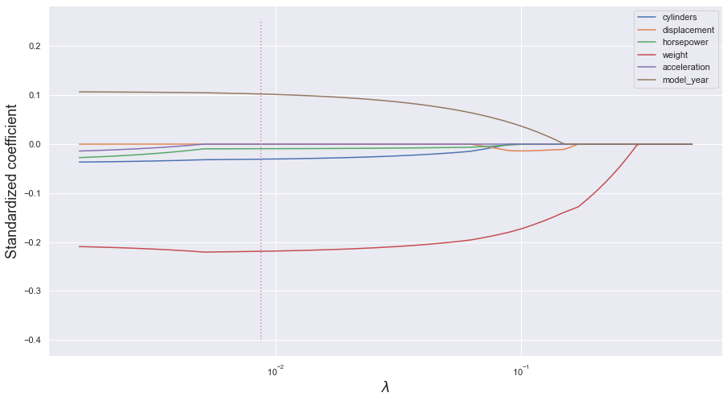

```python
#Visualizing the shrinkage in lasso coefficients with increasing values of the tuning parameter lambda

plt.xlabel('xlabel', fontsize=18)
plt.ylabel('ylabel', fontsize=18)
plt.plot(alphas, coefs)
plt.xscale('log')
plt.xlabel('$\lambda$')
plt.ylabel('Standardized coefficient')
plt.legend(train2[selected_cols]);
plt.plot([lassocv.alpha_,lassocv.alpha_],[-0.4,0.25],':')
plt.legend(train2[selected_cols]);
```

```python
#Test dataset
Xtest = test2[selected_cols]

#Standardizing test data
Xtest_std = scaler.transform(Xtest)

#Using the developed lasso model to predict on test data
lasso = Lasso(alpha = lassocv.alpha_)
lasso.fit(Xstd, y)
pred=lasso.predict(Xtest_std)

#Checking the coefficients of the lasso model
lasso.coef_
```

```
array([-0.03077496, -0.        , -0.00939007, -0.21885804, -0.        ,
        0.10234048])
```

```python
from sklearn.metrics import r2_score
lasso = Lasso(alpha = lassocv.alpha_)
lasso.fit(Xstd, y)

# Get the coefficients of the lasso model
lasso_coefs = lasso.coef_

# Get the names of the predictors
predictors = X.columns

# Remove any predictors that have a coefficient of zero
predictors = predictors[lasso_coefs != 0]

# Remove the corresponding coefficients
lasso_coefs = lasso_coefs[lasso_coefs != 0]
# Calculate R-squared for train and test sets
train_r2 = r2_score(y, lasso.predict(Xstd))
test_r2 = r2_score(test2.mpg, np.exp(pred))

# print the optimal value of the tuning parameter - lambda
print("Optimal alpha (lambda) value for lasso:", lassocv.alpha_)

# Create summary dataframe
lasso_summary = pd.DataFrame({'Predictors': predictors, 'Coefficients': lasso_coefs})

print(lasso_summary)

# print the RMSE on test data
print("RMSE on test data:", np.sqrt(((np.exp(pred)-test2.mpg)**2).mean()))

# print the R-squared values
print("R-squared on train data:", r2_score(lasso.predict(Xstd),y))
print("R-squared on test data:", r2_score(pred,np.log(test2.mpg)))
```

```
Optimal alpha (lambda) value for lasso: 0.00871316693004825
   Predictors  Coefficients
0   cylinders     -0.030775
1  horsepower     -0.009390
2      weight     -0.218858
3  model_year      0.102340
RMSE on test data: 3.167563835937625
R-squared on train data: 0.852077698896347
R-squared on test data: 0.8268172035554175
```

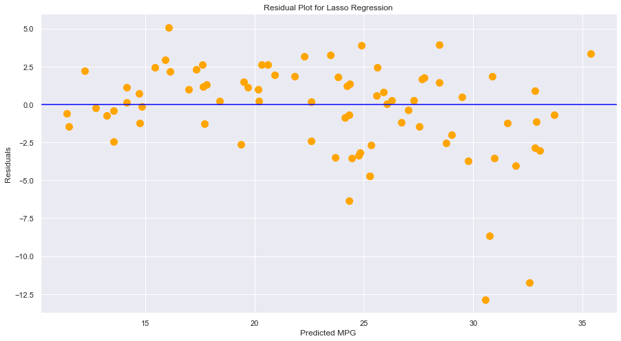

```python
# Residual plot

residuals = np.exp(pred) - test2.mpg
plt.scatter(np.exp(pred), residuals, color = 'orange')
plt.axhline(y=0, color='blue')
plt.xlabel('Predicted MPG')
plt.ylabel('Residuals')
plt.title('Residual Plot for Lasso Regression')
```

#### 3.1.3 Ridge Regression

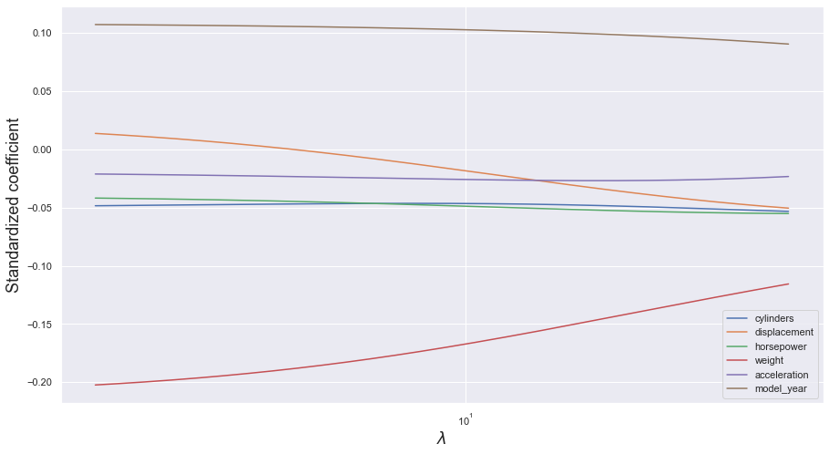

```python
#The tuning parameter lambda is referred as alpha in sklearn

#Creating a range of values of the tuning parameter to visualize the ridge regression coefficients
#for different values of the tuning parameter
alphas = 10**np.linspace(2,0.5,200)*0.5

#Finding the ridge regression coefficients for increasing values of the tuning parameter
coefs = []
for a in alphas:
    ridge = Ridge(alpha = a)
    ridge.fit(Xstd, y)
    coefs.append(ridge.coef_)

#Visualizing the shrinkage in ridge regression coefficients with increasing values of the tuning parameter lambda
plt.xlabel('xlabel', fontsize=18)
plt.ylabel('ylabel', fontsize=18)
plt.plot(alphas, coefs)
plt.xscale('log')
plt.xlabel('$\lambda$')
plt.ylabel('Standardized coefficient')
plt.legend(train2[selected_cols]);
```

```python
#Let us use cross validation to find the optimal value of the tuning parameter - lambda
#For the optimal lambda, the cross validation error will be the least

#Note that we are reducing the range of alpha so as to better visualize the minimum
ridgecv = RidgeCV(alphas = alphas,store_cv_values=True)
ridgecv.fit(Xstd, y)

#Optimal value of the tuning parameter - lambda
ridgecv.alpha_
```

```
2.6155496540281318
```

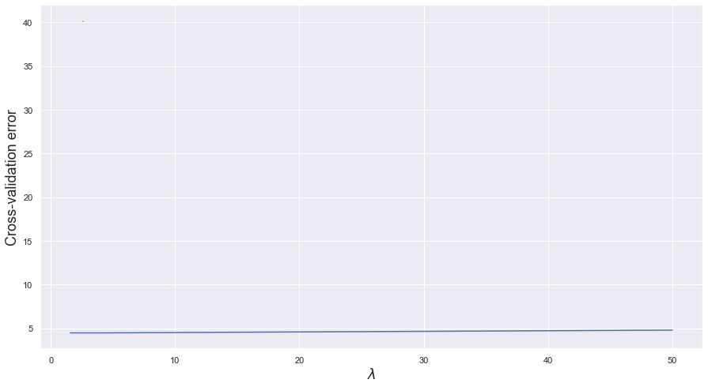

```python
#Visualizing the LOOCV (leave one out cross validatation error vs lambda)
plt.xlabel('xlabel', fontsize=18)
plt.ylabel('ylabel', fontsize=18)
plt.plot(ridgecv.alphas,ridgecv.cv_values_.sum(axis=0))
plt.plot([ridgecv.alpha_,ridgecv.alpha_],[40,40.2],':')
plt.xlabel('$\lambda$')
plt.ylabel('Cross-validation error')
```

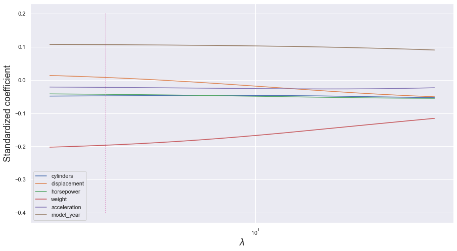

```python
#Visualizing the shrinkage in ridge regression coefficients with increasing values of the tuning parameter lambda
plt.xlabel('xlabel', fontsize=18)
plt.ylabel('ylabel', fontsize=18)
plt.plot(alphas, coefs)
plt.plot([ridgecv.alpha_,ridgecv.alpha_],[-0.4,0.2],':')
plt.xscale('log')
plt.xlabel('$\lambda$')
plt.ylabel('Standardized coefficient')
plt.legend(train2[selected_cols]);
```

```python
#Using the developed ridge regression model to predict on test data
ridge = Ridge(alpha = ridgecv.alpha_)
ridge.fit(Xstd, y)
pred=ridge.predict(Xtest_std)

#Checking the coefficients of the ridge regression model
ridge.coef_
```

```
array([-0.04768253,  0.00766862, -0.04306799, -0.19634448, -0.02218066,
        0.10637132])
```

```python
# get the coefficients
ridge_coefs = pd.DataFrame({'Predictors': X.columns, 'Coefficients': ridge.coef_})

# print the optimal value of the tuning parameter - lambda
print("Optimal alpha (lambda) value for ridge:", ridgecv.alpha_)

# print the coefficients
print("Coefficients:")
print(ridge_coefs)

# print the RMSE on test data
print("RMSE on test data:", np.sqrt(((np.exp(pred)-test2.mpg)**2).mean()))

# print the R-squared values
print("R-squared on train data:", r2_score(ridge.predict(Xstd),y))
print("R-squared on test data:", r2_score(pred,np.log(test2.mpg)))
```

```
Optimal alpha (lambda) value for ridge: 2.6155496540281318
Coefficients:
     Predictors  Coefficients
0     cylinders     -0.047683
1  displacement      0.007669
2    horsepower     -0.043068
3        weight     -0.196344
4  acceleration     -0.022181
5    model_year      0.106371
RMSE on test data: 3.2435304545205126
R-squared on train data: 0.8632261842398277
R-squared on test data: 0.8337438533286159
```

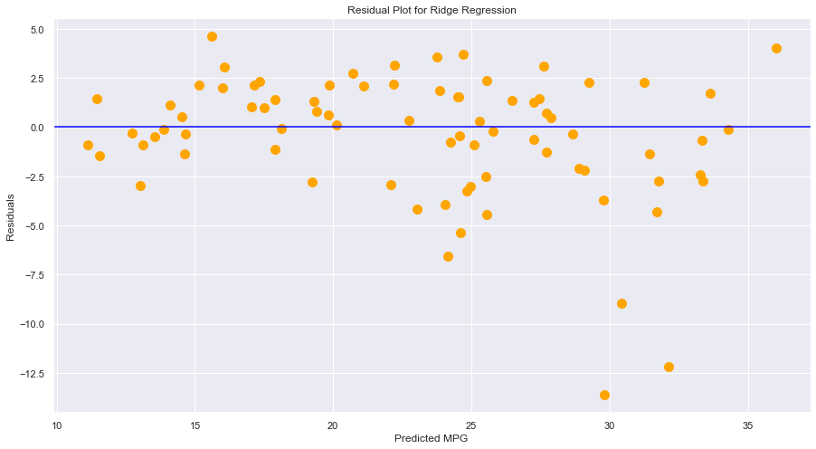

```python
# Residual plot

residuals = np.exp(pred) - test2.mpg
plt.scatter(np.exp(pred), residuals, color = 'orange')
plt.axhline(y=0, color='blue')
plt.xlabel('Predicted MPG')
plt.ylabel('Residuals')
plt.title('Residual Plot for Ridge Regression')
```

#### 3.1.4 Forward Stepwise Selection

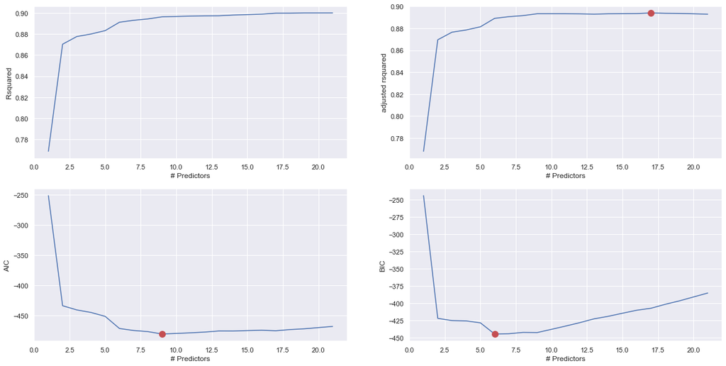

```python
# Doing forward selection with interaction terms

# suppress warning messages
import warnings
warnings.filterwarnings('ignore')

X = train_fwd[["cylinders", "displacement", "horsepower", "weight", "acceleration", "model_year"]]
X_backup = train_fwd[["cylinders", "displacement", "horsepower", "weight", "acceleration", "model_year"]]

for combo in itertools.combinations(X_backup.columns, 2):
    train_fwd['_'.join(combo)] = train_fwd[combo[0]]*train[combo[1]]
    test_fwd['_'.join(combo)] = test_fwd[combo[0]]*test[combo[1]]
    X.loc[:,'_'.join(combo)] = train_fwd.loc[:,'_'.join(combo)]

def processSubset(predictor_subset):
    model = smf.ols('np.log(mpg)~' + '+'.join(predictor_subset),data = train).fit()
    Rsquared = model.rsquared
    return {"model":model, "Rsquared":Rsquared}

def forward(predictors):

    remaining_predictors = [p for p in X.columns if p not in predictors]

    tic = time.time()

    results = []

    for p in remaining_predictors:
        results.append(processSubset(predictors+[p]))

    models = pd.DataFrame(results)

    best_model = models.loc[models['Rsquared'].argmax()]

    toc = time.time()

    return best_model

def forward_selection():
    models_best = pd.DataFrame(columns=["Rsquared", "model"]) # starts with empty dataframe

    tic = time.time()
    predictors = []

    for i in range(1,len(X.columns)+1):
        models_best.loc[i] = forward(predictors)
        predictors = list(models_best.loc[i]["model"].params.index[1:])

    toc = time.time()
    return models_best

models_best = forward_selection()

best_sub_plots()
```

We are using BIC for selecting the best number of predictors. Therefore, we will be using 6 predictors.

```python
# using 6 predictors from BIC evaluation
best_fwd_reg_model = models_best['model'][6]
best_fwd_reg_model.summary()
```

OLS Regression Results

| Dep. Variable: | np.log(mpg) | R-squared: | 0.891 |
| --- | --- | --- | --- |
| Model: | OLS | Adj. R-squared: | 0.889 |
| Method: | Least Squares | F-statistic: | 416.4 |
| Date: | Sat, 11 Mar 2023 | Prob (F-statistic): | 1.15e-143 |
| Time: | 17:03:32 | Log-Likelihood: | 242.59 |
| No. Observations: | 312 | AIC: | -471.2 |
| Df Residuals: | 305 | BIC: | -445.0 |
| Df Model: | 6 |  |  |
| Covariance Type: | nonrobust |  |  |

|  | coef | std err | t | P>\|t\| | [0.025 | 0.975] |
| --- | --- | --- | --- | --- | --- | --- |
| Intercept | 1.7778 | 0.622 | 2.859 | 0.005 | 0.554 | 3.001 |
| weight | -0.0003 | 0.000 | -1.174 | 0.241 | -0.001 | 0.000 |
| model_year | 0.0282 | 0.008 | 3.462 | 0.001 | 0.012 | 0.044 |
| horsepower_acceleration | -0.0003 | 4.89e-05 | -7.021 | 0.000 | -0.000 | -0.000 |
| weight_model_year | -6.28e-07 | 2.81e-06 | -0.224 | 0.823 | -6.15e-06 | 4.9e-06 |
| acceleration_model_year | 0.0003 | 5.82e-05 | 5.538 | 0.000 | 0.000 | 0.000 |
| horsepower_weight | 7.314e-07 | 1.55e-07 | 4.719 | 0.000 | 4.26e-07 | 1.04e-06 |

| Omnibus: | 10.023 | Durbin-Watson: | 1.901 |
| --- | --- | --- | --- |
| Prob(Omnibus): | 0.007 | Jarque-Bera (JB): | 17.788 |
| Skew: | -0.123 | Prob(JB): | 0.000137 |
| Kurtosis: | 4.144 | Cond. No. | 4.53e+07 |

Notes:  
[1] Standard Errors assume that the covariance matrix of the errors is correctly specified.  
[2] The condition number is large, 4.53e+07. This might indicate that there are  
strong multicollinearity or other numerical problems.

```python
# RMSE of model using forward stepwise selection
pred_mpg = np.exp(best_fwd_reg_model.predict(test_fwd))
print("RMSE of forward selection model", np.sqrt(((pred_mpg - test_fwd.mpg)**2).mean()))

# RMSE of model using all predictors
model = smf.ols('np.log(mpg)~' + '+'.join(X.columns),data = train_fwd).fit()
pred_mpg = np.exp(model.predict(test_fwd))
print("RMSE using all predictors and 2-factor interaction terms", np.sqrt(((pred_mpg - test_fwd.mpg)**2).mean()))
```

```
RMSE of forward selection model 2.8239865285927204
RMSE using all predictors and 2-factor interaction terms 2.488153062412976
```

### 3.2 Code for the final model (Forward Stepwise Selection with Interaction Terms)

#### 3.2.1 Model using variables found with forward-stepwise and var transformations

```python
model5 = smf.ols(formula = 'np.log(mpg) ~ horsepower*acceleration + acceleration*model_year + horsepower*weight + I(horsepower**2) + weight + weight*model_year + I(weight**2) + acceleration', data = train).fit()
model5.summary()
```

OLS Regression Results

| Dep. Variable: | np.log(mpg) | R-squared: | 0.896 |
| --- | --- | --- | --- |
| Model: | OLS | Adj. R-squared: | 0.892 |
| Method: | Least Squares | F-statistic: | 258.1 |
| Date: | Sat, 11 Mar 2023 | Prob (F-statistic): | 3.24e-141 |
| Time: | 17:04:22 | Log-Likelihood: | 248.96 |
| No. Observations: | 312 | AIC: | -475.9 |
| Df Residuals: | 301 | BIC: | -434.7 |
| Df Model: | 10 |  |  |
| Covariance Type: | nonrobust |  |  |

|  | coef | std err | t | P>\|t\| | [0.025 | 0.975] |
| --- | --- | --- | --- | --- | --- | --- |
| Intercept | 5.1309 | 1.521 | 3.373 | 0.001 | 2.138 | 8.124 |
| horsepower | -0.0004 | 0.003 | -0.123 | 0.902 | -0.007 | 0.006 |
| acceleration | -0.1545 | 0.068 | -2.287 | 0.023 | -0.288 | -0.022 |
| horsepower:acceleration | -0.0002 | 9.84e-05 | -2.189 | 0.029 | -0.000 | -2.18e-05 |
| model_year | -0.0101 | 0.018 | -0.556 | 0.579 | -0.046 | 0.026 |
| acceleration:model_year | 0.0022 | 0.001 | 2.685 | 0.008 | 0.001 | 0.004 |
| weight | -0.0007 | 0.000 | -2.819 | 0.005 | -0.001 | -0.000 |
| horsepower:weight | 6.133e-07 | 7.66e-07 | 0.800 | 0.424 | -8.95e-07 | 2.12e-06 |
| I(horsepower ** 2) | -4.203e-06 | 9.26e-06 | -0.454 | 0.650 | -2.24e-05 | 1.4e-05 |
| weight:model_year | 2.71e-06 | 3.15e-06 | 0.860 | 0.391 | -3.49e-06 | 8.91e-06 |
| I(weight ** 2) | 3.664e-08 | 2.43e-08 | 1.507 | 0.133 | -1.12e-08 | 8.45e-08 |

| Omnibus: | 10.717 | Durbin-Watson: | 1.936 |
| --- | --- | --- | --- |
| Prob(Omnibus): | 0.005 | Jarque-Bera (JB): | 20.855 |
| Skew: | -0.079 | Prob(JB): | 2.96e-05 |
| Kurtosis: | 4.257 | Cond. No. | 2.70e+09 |

Notes:  
[1] Standard Errors assume that the covariance matrix of the errors is correctly specified.  
[2] The condition number is large, 2.7e+09. This might indicate that there are  
strong multicollinearity or other numerical problems.

```python
pred_mpg = np.exp(model5.predict(test))
np.sqrt(((test.mpg - pred_mpg)**2).mean())
```

```
2.6668354165528805
```

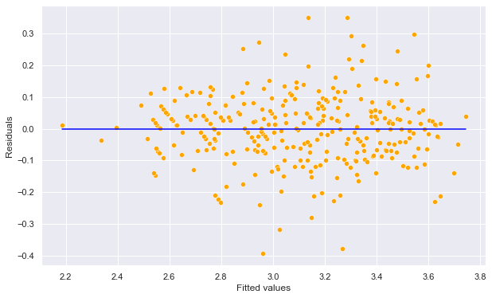

```python
#Plotting residuals vs fitted values
sns.set(rc={'figure.figsize':(10,6)})
sns.scatterplot(x = (model5.fittedvalues), y=(model5.resid),color = 'orange')
sns.lineplot(x = [model5.fittedvalues.min(),model5.fittedvalues.max()],y = [0,0],color = 'blue')
plt.xlabel('Fitted values')
plt.ylabel('Residuals')
```

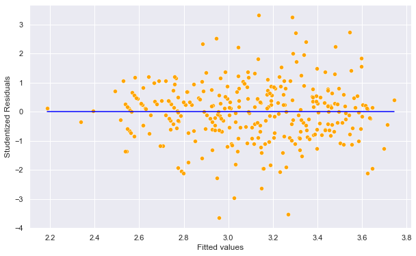

```python
#Studentized residuals
out = model5.outlier_test()

#Plotting studentized residuals vs fitted values
sns.scatterplot(x = (model5.fittedvalues), y=(out.student_resid),color = 'orange')
sns.lineplot(x = [model5.fittedvalues.min(),model5.fittedvalues.max()],y = [0,0],color = 'blue')
plt.xlabel('Fitted values')
plt.ylabel('Studentized Residuals')
```

```python
# Number of points with absolute studentized residuals greater than 3
np.sum((np.abs(out.student_resid)>3))
```

```
4
```

```python
# Computing the leverage statistic for each observation
influence = model5.get_influence()
leverage = influence.hat_matrix_diag
```

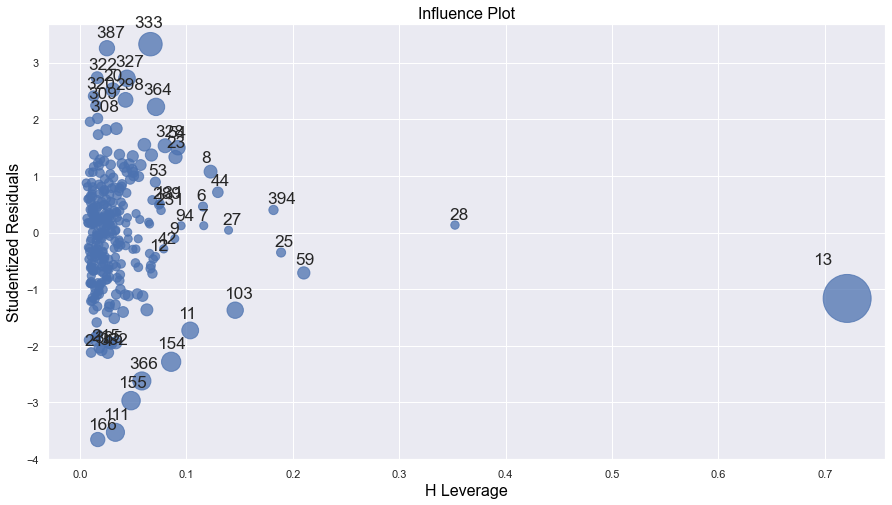

```python
# Visualizng leverage against studentized residuals
sns.set(rc={'figure.figsize':(15,8)})
sm.graphics.influence_plot(model5);
```